# Report: Ecosystems services multi-functionality and trade-offs

Olalla Díaz-Yáñez

14/08/2019

# Introduction

In this report I have tried to define the basic ideas that we discussed in the past and the results associated with it. I have also tried to explain the direction that I thought for the manuscript.

So far I have managed to calculate the results for 3 randomly selected blocks (last one is not completed yet).

## Main figures

I thought there is going to be three main figures in the article:

- Conceptual framework-explanatory figure (Not done yet)
- Multi-functionality effect on ecosystem services values
- Trade offs by pairs of ecosystem services (ES)

As discussed we will present in the manuscript only the results for one block. However, I think that as more results we have from other blocks we can better state that the trends are the same. The Figure 2 and 3 show the results for the block 1.

## Hypothesis of the paper

- H1: Multi-functional plans produce higher ES
- H2: The management perspectives selected in a multi-functional plan have an effect on the ES values
- H3: Trade offs between ES change with management perspective and multi-functionality of the plan

# FIG2. Multi-functionality effect on ecosystem services values

## Figure 2

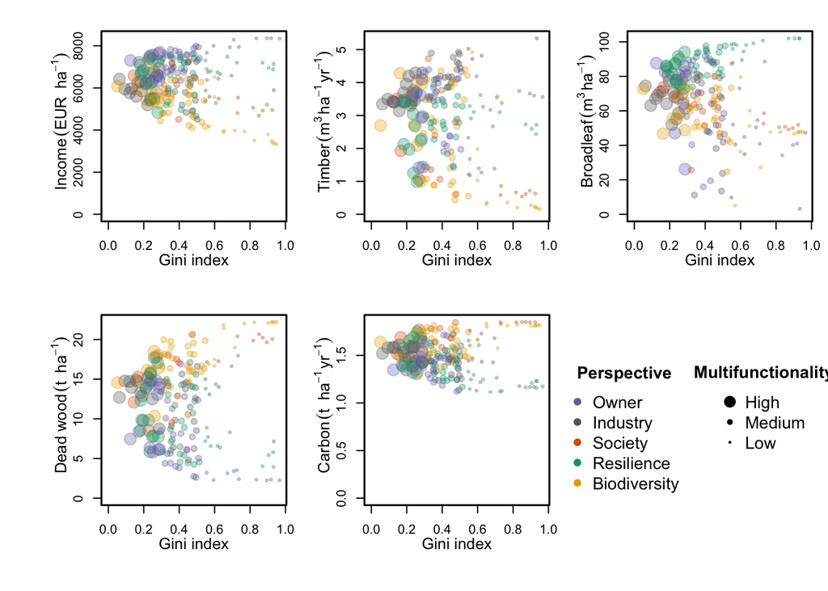

## Aim of the figure

The main goals of this figure is to answer the first and second hipothesis:

*Do more multifunctional plans produce higher ES values than less multifunctional plans?*

*Does the management perspective of a plan have an effect on ES values?*

## Description of the figure

Here we are seeing the 200 plans developed for 200 different weigths that were selected randonmly for each of the 5 selected **ecosystem services**:

- Income (NPV 2%)
- Round wood drain (for all periods together 2016-2115)
- Broadleaf volume (at the end of 100 years 2116)
- Dead wood (at the end of 100 years 2116)
- Carbon balance (for all periods together 2016-2115)

With **weights** I mean the “importance” that in each plan each ES has. The weights of the 200 plans have the following characteristics:

- The weights are always above 0 for any ES and plan
- They were selected randomly
- The lower value across the three blocks for any ES is 0.001% (and the highest-lowest value 0.1%)
- The highest value across the three blocks for any ES is 97% (and the lowest-highest value 83%)

The weights have been also used to define the **Gini index** as a measurement of the **multi-functionality level**. For each management plan I have calculated the Gini Index of its weights. If the Gini is low, it means that the weights are more similar, more equally distributed, and therefore we have a more multi-functional plan, and vice-versa.

I have included the term **management perspective** that I have been trying to define in the introduction. I know they are not the most appropriate / correct terms, however, since were are aiming for a journal with a high audience spectrum, specially compared to a forestry journal, I thought this could be a way of making the results more general and understandable for everybody. The idea is that each of the ecosystem services that we have used, represent a management perspective (I am trying to well document this in the introduction with references and my preliminary idea is that the figure 1 would define this framework properly based on this small literature review). The management perspective is assigned to each management plan corresponding with the ES indicator with highest weight for that management.

The management perspectives are:

- **Owner**-Money (Income-NPV2%)
- **Industry**-Timber (Round wood drain)
- **Society (or maybe climate change?)**-Carbon (Carbon balance)
- **Resilience**-Presence of broadleaves (Broadleaves volume)
- **Biodiversity**-Presence of deadwood (Dead wood)

## Main results

### Do more multi-functional plans produce higher ES values than less multi-functional plans?

Unfortunately the trends are not crystal clear or at least I am not sure anymore if we can truly state, based in our results, that *More multi-functional plans increase ES values*.

I do not think we should show these models in the results section, maybe only just stating that the trends models were done and showed positive trends for certain ES.

Here you can see the models plotted over the figure 1 for the three blocks and the summary of the trend models:

#### Block 1

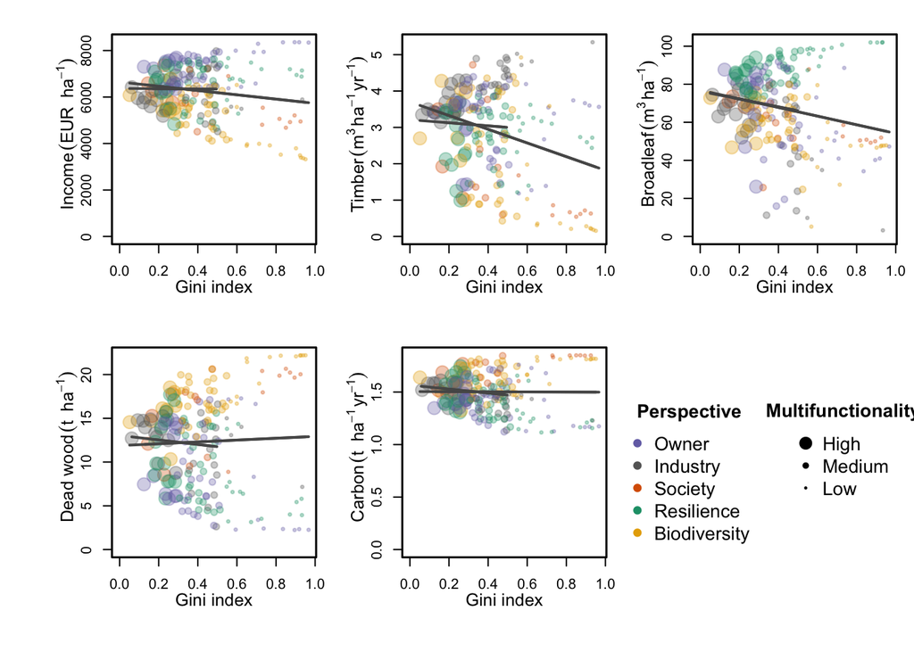

*The shortest trend line represent the trends for those plans that have Gini index bellow 0.5.

**NPV trend model**

|  | Estimate | Std. Error | t value | Pr(>\|t\|) |
| --- | --- | --- | --- | --- |
| (Intercept) | 6648.61 | 191.32 | 34.75 | 0.00 |
| table$GiniES | -922.18 | 389.06 | -2.37 | 0.02 |

| R-squared |
| --- |
| 0.0276 |

**Timber trend model**

|  | Estimate | Std. Error | t value | Pr(>\|t\|) |
| --- | --- | --- | --- | --- |
| (Intercept) | 3.70 | 0.21 | 18.04 | 0 |
| table$GiniES | -1.88 | 0.42 | -4.51 | 0 |

| R-squared |
| --- |
| 0.0933 |

**Broadleaf trend model**

|  | Estimate | Std. Error | t value | Pr(>\|t\|) |
| --- | --- | --- | --- | --- |
| (Intercept) | 76.88 | 3.49 | 22.02 | 0 |
| table$GiniES | -22.73 | 7.10 | -3.20 | 0 |

| R-squared |
| --- |
| 0.0492 |

**Dead wood trend model**

|  | Estimate | Std. Error | t value | Pr(>\|t\|) |
| --- | --- | --- | --- | --- |
| (Intercept) | 11.88 | 0.92 | 12.96 | 0.00 |
| table$GiniES | 1.05 | 1.86 | 0.56 | 0.57 |

| R-squared |
| --- |
| 0.0016 |

**Carbon balance trend model**

|  | Estimate | Std. Error | t value | Pr(>\|t\|) |
| --- | --- | --- | --- | --- |
| (Intercept) | 1.51 | 0.03 | 45.58 | 0.00 |
| table$GiniES | -0.01 | 0.07 | -0.09 | 0.93 |

| R-squared |
| --- |
| 0 |

#### Block 5

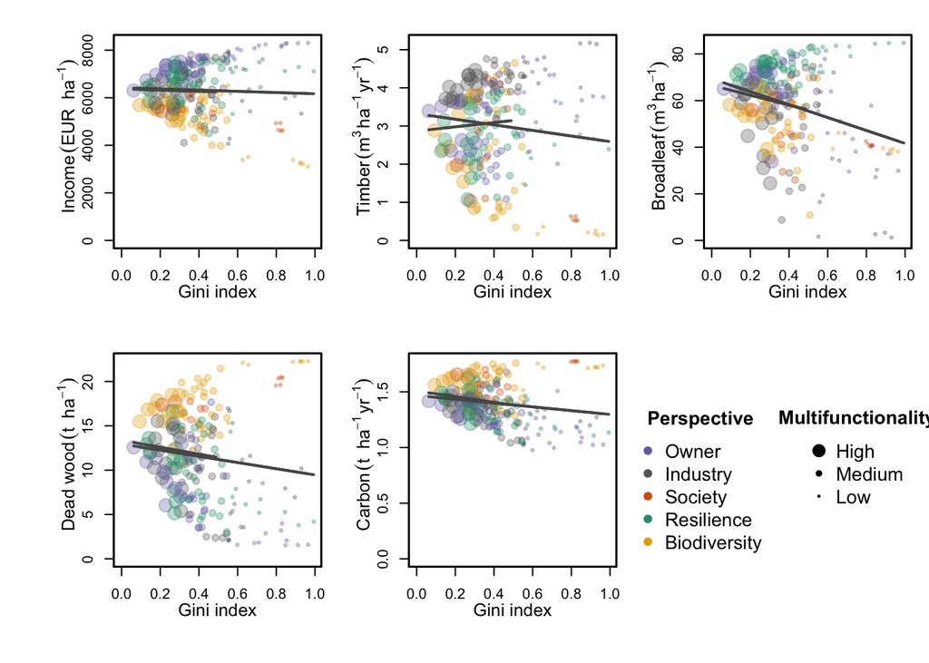

*The shortest trend line represent the trends for those plans that have Gini index bellow 0.5.

**NPV trend model**

|  | Estimate | Std. Error | t value | Pr(>\|t\|) |
| --- | --- | --- | --- | --- |
| (Intercept) | 6424.91 | 205.46 | 31.27 | 0.00 |
| table$GiniES | -258.84 | 419.27 | -0.62 | 0.54 |

| R-squared |
| --- |
| 0.0019 |

**Timber trend model**

|  | Estimate | Std. Error | t value | Pr(>\|t\|) |
| --- | --- | --- | --- | --- |
| (Intercept) | 3.32 | 0.22 | 15.30 | 0.0 |
| table$GiniES | -0.73 | 0.44 | -1.65 | 0.1 |

| R-squared |
| --- |
| 0.0136 |

**Broadleaf trend model**

|  | Estimate | Std. Error | t value | Pr(>\|t\|) |
| --- | --- | --- | --- | --- |
| (Intercept) | 69.37 | 2.98 | 23.24 | 0 |
| table$GiniES | -27.75 | 6.09 | -4.56 | 0 |

| R-squared |
| --- |
| 0.0949 |

**Dead wood trend model**

|  | Estimate | Std. Error | t value | Pr(>\|t\|) |
| --- | --- | --- | --- | --- |
| (Intercept) | 12.95 | 0.95 | 13.62 | 0.00 |
| table$GiniES | -3.49 | 1.94 | -1.80 | 0.07 |

| R-squared |
| --- |
| 0.0161 |

**Carbon balance trend model**

|  | Estimate | Std. Error | t value | Pr(>\|t\|) |
| --- | --- | --- | --- | --- |
| (Intercept) | 1.47 | 0.03 | 44.0 | 0.00 |
| table$GiniES | -0.17 | 0.07 | -2.5 | 0.01 |

| R-squared |
| --- |
| 0.0306 |

#### Block 11

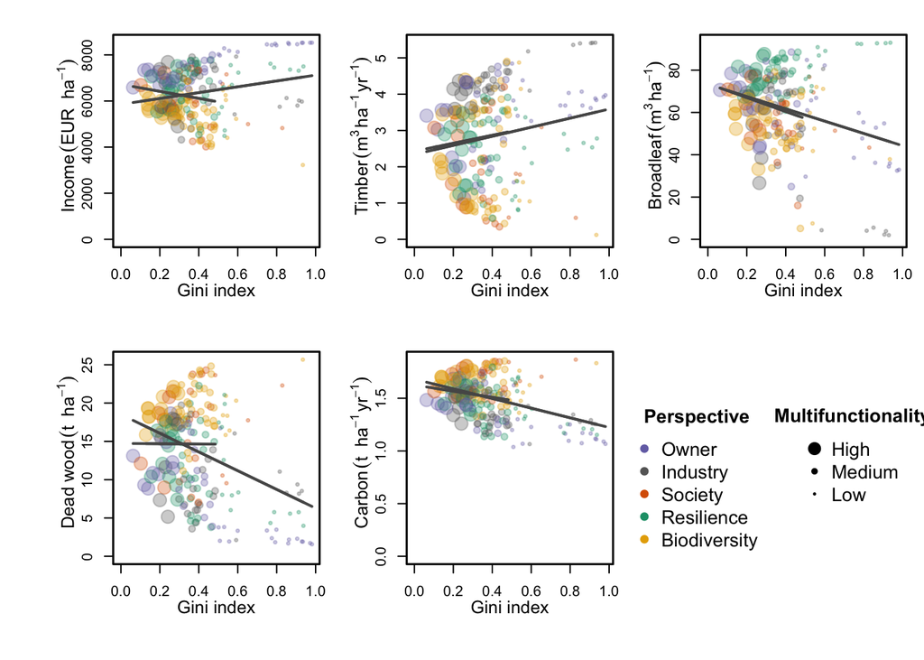

*The shortest trend line represent the trends for those plans that have Gini index bellow 0.5.

**NPV trend model**

|  | Estimate | Std. Error | t value | Pr(>\|t\|) |
| --- | --- | --- | --- | --- |
| (Intercept) | 5855.37 | 190.11 | 30.80 | 0 |
| table$GiniES | 1266.60 | 409.35 | 3.09 | 0 |

| R-squared |
| --- |
| 0.0461 |

**Timber trend model**

|  | Estimate | Std. Error | t value | Pr(>\|t\|) |
| --- | --- | --- | --- | --- |
| (Intercept) | 2.34 | 0.22 | 10.71 | 0.00 |
| table$GiniES | 1.25 | 0.47 | 2.66 | 0.01 |

| R-squared |
| --- |
| 0.0344 |

**Broadleaf trend model**

|  | Estimate | Std. Error | t value | Pr(>\|t\|) |
| --- | --- | --- | --- | --- |
| (Intercept) | 73.32 | 3.17 | 23.11 | 0 |
| table$GiniES | -29.05 | 6.83 | -4.25 | 0 |

| R-squared |
| --- |
| 0.0836 |

**Dead wood trend model**

|  | Estimate | Std. Error | t value | Pr(>\|t\|) |
| --- | --- | --- | --- | --- |
| (Intercept) | 18.51 | 0.99 | 18.63 | 0 |
| table$GiniES | -12.23 | 2.14 | -5.72 | 0 |

| R-squared |
| --- |
| 0.1417 |

**Carbon balance trend model**

|  | Estimate | Std. Error | t value | Pr(>\|t\|) |
| --- | --- | --- | --- | --- |
| (Intercept) | 1.68 | 0.03 | 52.54 | 0 |
| table$GiniES | -0.46 | 0.07 | -6.65 | 0 |

| R-squared |
| --- |
| 0.1827 |

### Does the management perspective of a plan have an effect on ES values?

- For all the ES, it seems that for high and medium multi-functional plans the management perspective effect in the ES value has a lower impact than for low multi-functional plans
- Low multi-functional plans show more distinct ES values on potentially conflicting management perspectives (e.g. when plotting carbon, for less multi-functional plans there is a clear difference between plans with a management perspective on biodiversity (dead wood) and society (carbon) showing the highest carbon values, than those plans with a management perspectives of owner (money, NPV2), industry (timber) and resilience (broadleaf volumes))

# FIG3. Ecosystem services trade-offs

## Figure 3

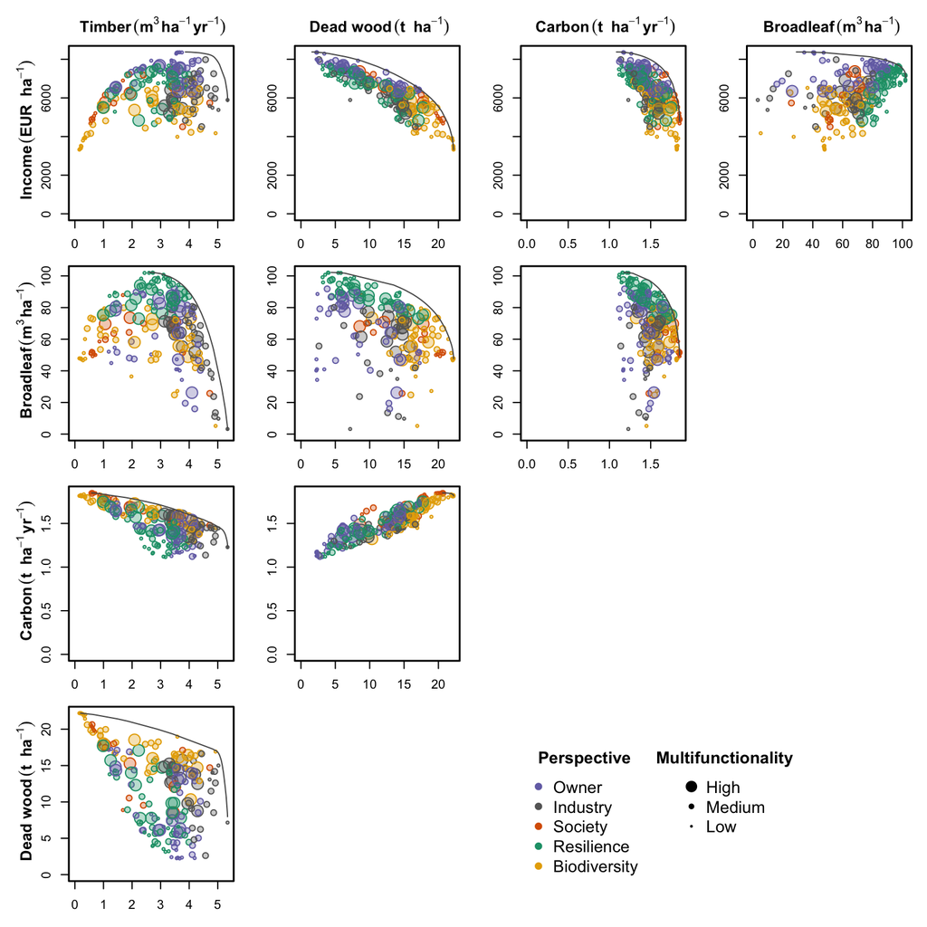

## Aim of the figure

The main goal of this figure is to answer the third hypothesis:

*How the ES trade-offs change for different management perspectives and multi-functionality of the plans?*

## Description of the figure

In this figure we are also seeing the 200 multi-functional plans, with the colors defining the **management perspective** and the size of the dots the **multi-functionality level** of each plan. They are plotted for each pair of **ecosystem services**.

The lines represent another 50 management plans where the weights were 0 for the other ES, so we just maximized the values for the ES pair that we are showing in the plot.

## Main results

### How the ES trade-offs change for different management perspectives and multi-functionality of the plans?

- For all the ES pairs, the trade-offs do not show a pattern with respect of the plans multi-functionality
- Income trade-off with dead wood and carbon, broadleaf trade-off with carbon, and carbon trade-off with timber show that most of the plans are closer to the production probability frontier curve or efficient curve.
- When comparing carbon and dead wood there is no trade-off, increasing values of carbon increases the values of dead wood
- The highest conflicts are between dead wood and timber, where increasing timber values always decrease dead-wood values